# Cameron B. Chiarot, MBA, PhD

Epidemiologist & Health Economist | RWE & HEOR Strategist | Executive Leader

## Executive Summary

### Bridging Executive Impact & Scientific Rigour

I am a global Health Economist, Epidemiologist, Biostatistician, and Strategic Leader offering a unique dual background: a PhD in health systems research and disease modelling and an MBA in economics and finance. For over **two decades**, I have operated at the intersection of **rigorous scientific inquiry and executive decision-making**. My core focus is translating complex longitudinal health data and advanced epidemiological and econometric modelling into actionable clinical, commercial, and policy insights. By bridging the gap between implementation science and large-scale organizational transformation, I empower cross-disciplinary teams to drive evidence-based strategy, optimize market access, and ensure long-term financial sustainability across complex health organizations and ecosystems.

### Global Research Ecosystems & Academic Integration

My work encompasses both high- and low-resource settings internationally, including Canada, the United States, the United Kingdom, and the Republic of Zambia. Presently, I hold positions as a Research Scientist Collaborator with Imperial College London, an Instructor at the University of Waterloo’s School of Public Health Sciences, and an Adjunct Professor at York University’s Schulich School of Business. In these capacities, **I am committed to fostering inclusive, interdisciplinary research environments** and securing funding from external tri-council agencies and industry partners. Whether examining global disease surveillance systems or developing outcomes-focused curricula for higher education, my primary objective is to promote applied innovation and mentor the next generation of health systems leaders.

### Interdisciplinary Scholarship & Professional Distinction

My academic foundation comprises a **PhD** in **Health Economics**, **Epidemiology**, and **Biostatistics** from the University of Waterloo, during which I was nominated for the esteemed Governor General’s Gold Medal in recognition of outstanding academic achievement and distinguished scholarship. I also possess an **MBA** in **Economics**, **Finance**, and **Health Systems** from the Schulich School of Business at York University, graduating with Distinction as a member of the Dean’s List. Previously, I earned a **BSc (Hon)** in **Psychology** and **Neuroscience** from the University of Western Ontario, completing an honours thesis that ranked within the top 5%. Furthermore, I hold a certificate from the **Executive Leadership Development Program** in **Healthcare Management** at the University of Toronto’s Rotman School of Management, in addition to my **TCPS 2: CORE Certification** from the Panel on Research Ethics.

## Core Competencies Matrix

The following chart outlines my hybrid expertise across advanced scientific methodologies and executive leadership, highlighting the years of applied experience driving health outcomes and financial acumen in each domain.

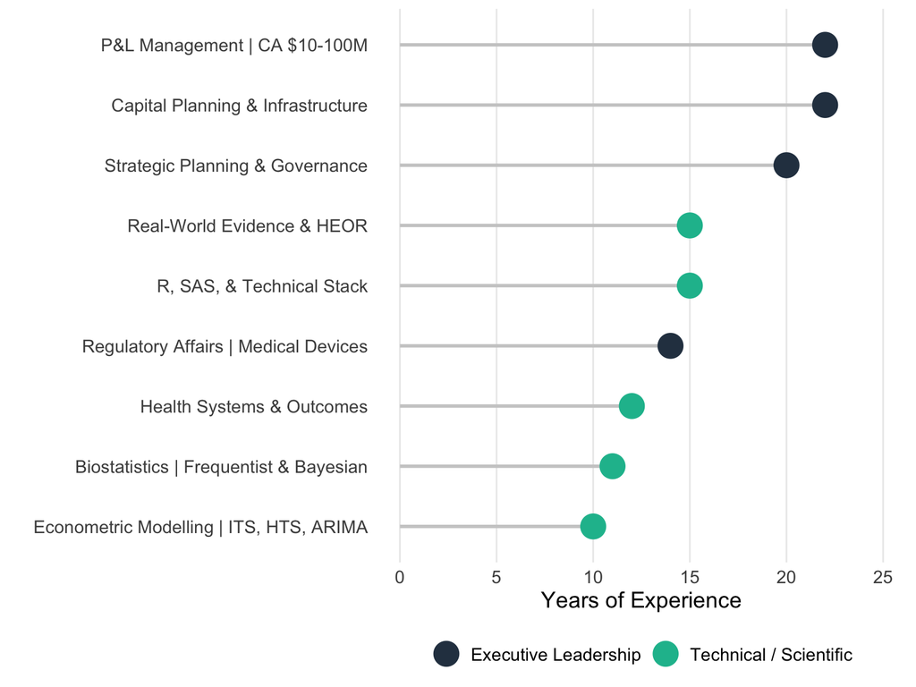

Figure 1: Core Competencies: Executive & Scientist

## Leadership Philosophy & Collaborative Ecosystems

#### Interdisciplinary Synergy

Bridging institutional silos to align technical data scientists, clinical practitioners, and executive decision-makers.

#### 'Sandbox' Environments

Cultivating psychological safety and methodological experimentation to push the boundaries of outcomes research.

#### Capacity Building

Mentoring high-performing teams and elevating the overarching analytical capabilities of the organization.

#### Equity & Inclusion

Driving systemic organizational equity by building diverse, high-performing teams and fostering a culture of belonging and equitable opportunity.

## Executive Impact Highlights

The following metrics represent my key operational, financial, and regulatory milestones achieved through the application of data-driven strategy and executive leadership.

## $100M

P&L Management

Oversight of operational capital and cross-functional institutional budgets.

## 270 Days

Wait Time Reduction

Achieved via Lean data analytics and process-enhancement initiatives.

## $25M

Capital Savings

Realized through strategic infrastructure grants and asset alignment.

## 6 Months

Regulatory Approval

Accelerated timeline for Health Canada Class III Medical Device authorizations.

## $1.5M

Annualized Savings

Generated through comprehensive financial analysis and strategic lease negotiations.

## $5.0M

Strategic Funding

Secured major philanthropic capital investments to drive R&D infrastructure initiatives.

## RWE & HEOR Portfolio

My applied research portfolio bridges advanced epidemiology and biostatistics with global health economics. Click on the strategic pillars below to explore the specific outcome targets, methodological frameworks, and insights of my evidence-generation corpus.

**Health Economics & Systems Resilience +**

#### Health System Utilization

- **Focus:** Environmental Shocks & Health Resilience | **Method:** Interrupted Time Series (ITS)  
  *Insight:* Evaluated utilization shifts and systemic resilience with high point estimate precision.
- **Focus:** Econosyndemics & Health Stressors | **Method:** Structural Equation Modelling (SEM)  
  *Insight:* Identified systemic utilization drivers via structural causal models.

#### Maternal Continuum of Care

- **Focus:** Climate Shocks & Systemic Stressors | **Method:** Quasi-Experimental Design  
  *Insight:* Assessed continuum of care resilience against exogenous climate shocks.

#### Financial Burden & Economics of Scale

- **Focus:** Financial Burden of Free Healthcare | **Method:** Multivariable Regression  
  *Insight:* Quantified out-of-pocket financial burdens impacting healthcare utilization.
- **Focus:** HIV Care Economies of Scale | **Method:** Cross-Sectional Analysis  
  *Insight:* Modeled scaling efficiencies and financial sustainability in care delivery.

#### Universal Health Coverage (UHC)

- **Focus:** Access as a Dimension of UHC | **Method:** Empirical Evaluation  
  *Insight:* Empirically assessed systemic access barriers inhibiting universal coverage.

**Spatial & Infectious Disease Epidemiology +**

#### Malaria Surveillance

- **Focus:** Malaria Denominators | **Method:** Spatial Catchment Methodology  
  *Insight:* Refined spatial catchment models to optimize surveillance denominators.

#### Maternal Healthcare Access

- **Focus:** Hydrological Shifts & Maternal Care | **Method:** Hydrological & Spatial Mapping  
  *Insight:* Mapped spatial barriers to maternal care access against hydrological data.

#### Universal Health Coverage (UHC)

- **Focus:** Spatial Inequities in Primary Care | **Method:** Location-Allocation Analysis  
  *Insight:* Analyzed primary care access inequities to inform location-allocation.

#### Geospatial Publication Integrity

- **Focus:** Nigerian Twinning Publication Bias | **Method:** Geospatial Meta-Analysis  
  *Insight:* Evaluated geospatial reporting integrity and spatial publication biases.

#### Mental Health

- **Focus:** COVID-19 Student Anxiety | **Method:** Systematic Review  
  *Insight:* Reviewed systemic mental health impacts using rigorous evidence synthesis.

**Advanced Biostatistics & Trial Diagnostics +**

#### HIV/AIDS Structural Risk

- **Focus:** PopART Risk & Friction Audit | **Method:** Frequentist & Bayesian Regression  
  *Insight:* Audited structural risk and trial friction with robust point estimate precision.

[View Google Scholar Profile](https://scholar.google.com/citations?user=02J5Ti0AAAAJ&hl=en)

## Pedagogical Innovation & Open-Source Architecture

A core component of my professional ecosystem is mentoring the next generation of health system leaders and building institutional analytical capacity. As the developer of the course “Value and Quality in Healthcare” (MHIA 6160) curriculum at York University’s Schulich School of Business, I bridge the gap between technical data science and healthcare administration. My pedagogical approach prioritizes the creation of interactive ‘sandbox’ learning environments built entirely on open-source R, RStudio, and public modelling interfaces, empowering students with accessible, reproducible tools for evidence-based decision-making.

### Current Collaborative & Adjunct Appointments

These roles represent my active, collaborative, and contract academic engagements, running in parallel with my executive and industry pursuits:

- **Research Scientist Collaborator** | *Imperial College London, London, UK*
- **Adjunct Professor** | *Schulich School of Business, York University, Toronto, Canada*
- **Sessional Lecturer** | *School of Public Health Sciences, University of Waterloo, Waterloo, Canada*

## Open to Strategic Opportunities

Dr. Chiarot is actively open to opportunities that leverage his unique intersection of rigorous health systems and outcomes research and executive leadership. With a proven track record of bridging the gap between advanced biostatistical modelling and organizational strategy, he is currently exploring roles including:

- **Senior Industry Leadership:** Executive, Director, or Principal Scientist roles focusing on HEOR, RWE, and Market Access.
- **Executive Management:** Strategic oversight of research infrastructure, clinical operations, applied innovation and intellectual property, P&L management, dynamic collaboration, mentorship, and stakeholder engagement.
- **Consultancy & Advising:** Specialized consulting for public health initiatives, regulatory submissions, and advanced statistical and econometric modelling.
- **Academic Collaboration:** Applied health systems and outcomes research and outcomes-based dynamic curriculum development (i.e., theory & applied)

Email Dr. Chiarot [Connect on LinkedIn](https://www.linkedin.com/in/cameronchiarot)

**{end}**